# Using R to Process Weather Data

7/20/2016

## R Resources for Climate Data

## Tutorials and Libraries

Numerous resources are available that might help us (beside this document!) access and process weather data.

Here is a preliminary list:

- [R Blogger to Access, Clean, and Plot NOAA tempeature data](http://www.r-bloggers.com/accessing-cleaning-and-plotting-noaa-temperature-data/)
- Next…suggestions?

## Accessing the Data

## What sites are available for downloading the data?

- [NCDC–NOAA Datasets](https://www.ncdc.noaa.gov/cdo-web/datasets)

For this project, the Global Historical Climate Network may be the most useful data, which can be downloaded from the following an ftp site, where I downloaded the entire dataset for the class!

## Stations in NOAA Database

## NOAA isd-history

NOAA has a list of sites in the isd-history , but I have not investigated the source of the data or how this fits with other datasets.

Note: read.fwf generates unknown variable "X1", "X2", etc.

```
##         USAF X1  WBAN X2                  STATION_NAME X3 CTRY  X4 ST X5
## 30      8409 NA 99999 NA XM13
## 4000  120010 NA 99999 NA PETROBALTIC BETA                   PL
## 20000 725290 NA 14768 NA GREATER ROCHESTER INTERNATION      US     NY
##       CALL X6    LAT X7     LON X8  ELEV X9    BEGIN X10      END
## 30         NA     NA NA      NA NA    NA NA 20091027  NA 20100104
## 4000       NA 55.467 NA  18.167 NA  46.0 NA 20141127  NA 20141127
## 20000 KROC NA 43.117 NA -77.677 NA 164.3 NA 19730101  NA 20160724
```

```
##           ID  WBAN    Lat     Lon
## 30      8409 99999     NA      NA
## 4000  120010 99999 55.467  18.167
## 20000 725290 14768 43.117 -77.677
```

## Map of Weather Stations (source: NOAA ISD??)

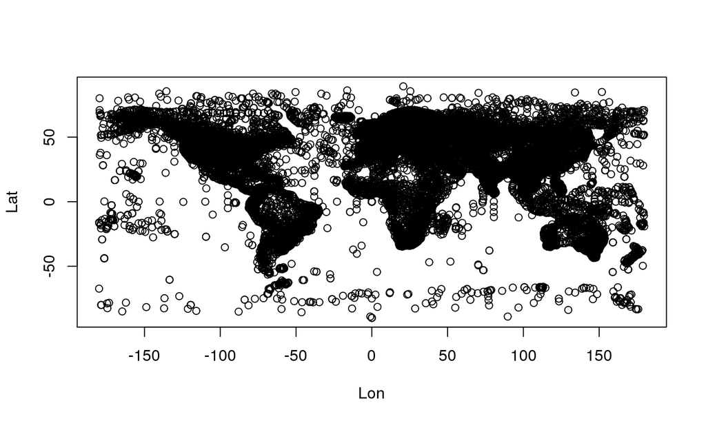

## Download Weather Data

## Identify URLs for data source

Once finding data sources, you might find URLs with ftp or http protocols – it shouldn't matter which type you find.

For example, using the NOAA's website, I found the following URL, ftp://ftp.ncdc.noaa.gov/pub/data/ghcn/daily/, to download data from the Global Historical Climatalogical Network (GHCDN), where an entire dataset can be downloaded.

Alternatively, another NCDC-NOAA Directory seems to have data by year. But please look at the readme.txt that describes the data and let me know and I will make a note of what it contains.

## GHCND Data

One major source of data is the GHCND. I downloaded the file to my computer, then uploaded some example data into the R project Data directory.

```r
gzfile = "ftp://ftp.ncdc.noaa.gov/pub/data/ghcn/daily/ghcnd_all.tar.gz"
```

The file source URL is ftp://ftp.ncdc.noaa.gov/pub/data/ghcn/daily/ghcnd_all.tar.gz. There are two things you should note about this file.

1. It's located on an ftp ("file transfer protocol"), where one can create automatic update scripts to avoid analyzing out of date files.
2. It is compressed (gz and tar are compression methods.) Thus, the file required some pre-processing, in particular, to uncompressed.

## How to Uncompress Data

Files storing centuries of weather data from thousands of sites can become quite large. Thus, the files are compressed. There are a number of compression methods, available, e.g. zip, gz, and tar. Fortunately, we can use R to uncompress a range of compressed file types.

It takes a while (2+ hours) to uncompress (first gz -> tar -> readable files), so I have done that already and loaded some of the data into the github site.

```
## [1] "AGE00147708.dly" "AGM00060515.dly" "US1AZCN0021.dly" "US1AZMR0019.dly"
## [5] "US1AZMR0026.dly" "US1CAAL0001.dly" "XYZ_dly.csv"
```

## Regional Datasets–Finding Stations

Since we are interested in a more regional approach, you may want to find a less daunting file.

## Processing Imported Data

## Creating Variable Names

Since the data don't come with headers (variable names), we need to assign them. This can be a long and frustating activity. Below, I did some mettling to attempt this.

```r
names(stations)= c("ID", "LAT", "LONG", "ELEV", "STATE", "NAME", "GSN", "HCN_CRN", "WHOID")
```

## Stations with Assign Variable Names

```
##            ID     LAT     LONG  ELEV STATE
## 1 ACW00011604 17.1167 -61.7833  10.1
## 2 ACW00011647 17.1333 -61.7833  19.2
## 3 AE000041196 25.3330  55.5170  34.0
## 4 AEM00041194 25.2550  55.3640  10.4
## 5 AEM00041217 24.4330  54.6510  26.8
## 6 AEM00041218 24.2620  55.6090 264.9
##                               NAME GSN HCN_CRN WHOID
## 1  ST JOHNS COOLIDGE FLD                          NA
## 2  ST JOHNS                                       NA
## 3  SHARJAH INTER. AIRP             GSN         41196
## 4  DUBAI INTL                                  41194
## 5  ABU DHABI INTL                              41217
## 6  AL AIN INTL                                 41218
```

## Structure of imported data

```
## 'data.frame':    100747 obs. of  9 variables:
##  $ ID     : Factor w/ 100747 levels "ACW00011604",..: 1 2 3 4 5 6 7 8 9 10 ...
##  $ LAT    : num  17.1 17.1 25.3 25.3 24.4 ...
##  $ LONG   : num  -61.8 -61.8 55.5 55.4 54.7 ...
##  $ ELEV   : num  10.1 19.2 34 10.4 26.8 ...
##  $ STATE  : Factor w/ 76 levels "   "," AB"," AK",..: 1 1 1 1 1 1 1 1 1 1 ...
##  $ NAME   : Factor w/ 93968 levels " 'S HEERENHOEK                  ",..: 79235 79234 76245 23599 287 949 61012 36770 41695 42069 ...
##  $ GSN    : Factor w/ 3 levels "","   ","GSN": 2 2 3 2 2 2 3 2 2 2 ...
##  $ HCN_CRN: Factor w/ 4 levels "","    "," CRN",..: 2 2 2 2 2 2 2 2 2 2 ...
##  $ WHOID  : num  NA NA 41196 41194 41217 ...
```

## Records from One Location

Here's an example of data from Arizona

```
##                ID     LAT      LONG  ELEV STATE
## 48124 US1AZMR0019 33.5902 -111.9712 418.5    AZ
##                                   NAME GSN HCN_CRN WHOID
## 48124  SCOTTSDALE 8.8 SW                              NA
```

Now we can locate the site location from this file.

## Getting Weather Data from Specific Locations

Copy the URL into a clipboard and then create a object with the link, so let's download the Arizona file.

### Create a Folder for Data

Once a site URL has been identified, we can use R to download the data into a specific directory. I suggest you create a subdirectory within Data that you can track and store your data.

### Download the Data

Note: The site can stall, so be careful when trying to download large files via web browers.

## Reading Data into R

## What is the data format?

Before reading data, we need to determine the file structure. For example, XX data has the following format, where headers are lost and each column is separated by tabs that are lost in text rendions. Thus, we'll need a key to intepret the data.

AG000060680 22.8000 5.4331 1362.0 TAMANRASSET GSN 60680

Thankfully, there is a readme.tex file that provides a key to the file structure. I suggest you read it carefully and to understand what is in the database.

## File Structure Keys

Although these keys are a bit daunting to read at first, we will appreciate the consistancy soon! Below is the structure of dly files, which is cut off, so be sure the check out the readme.txt file for a complete list:

| Parameter | Columns | Variable Type |
| --- | --- | --- |
| ID | 1-11 | Character |
| YEAR | 12-15 | Integer |
| MONTH | 16-17 | Integer |
| ELEMENT | 18-21 | Character |
| VALUE1 | 22-26 | Integer |
| MFLAG1 | 27-27 | Character |
| QFLAG1 | 28-28 | Character |
| SFLAG1 | 29-29 | Character |
| VALUE2 | 30-34 | Integer |
| MFLAG2 | 35-35 | Character |
| QFLAG2 | 36-36 | Character |
| SFLAG2 | 37-37 | Character |
| . | . | . |
| . | . | . |
| . | . | . |
| VALUE31 | 262-266 | Integer |
| MFLAG31 | 267-267 | Character |
| QFLAG31 | 268-268 | Character |
| SFLAG31 | 269-269 | Character |

## Processing Data

## Creating Loops

I often forget how to make loops, so I often use simple examples that help me remember, for example,

```
## [1] "The year is 2010"
## [1] "The year is 2011"
## [1] "The year is 2012"
## [1] "The year is 2013"
## [1] "The year is 2014"
## [1] "The year is 2015"
```

Since the data have a re-occuring set of variable names, I decided to create a vector of variable names, many of which are nearly the same. So, as you'll see, I had to create a loop to avoid having to type a ton (or 31 :-)) of different variables.

```
## [1] 128
```

## Process Selected Data Files

## Reading .dly file into R

Now that we have a good idea of what these files look like, I have created a loop to read the files and select the rows where the maximum temperature was recorded ("TMAX").

```
## [1] "/home/CAMPUS/mwl04747/github/Climate_Change_Narratives/Data"
```

```
## [1] "AGE00147708.dly" "AGM00060515.dly" "US1AZCN0021.dly" "US1AZMR0019.dly"
## [5] "US1AZMR0026.dly" "US1CAAL0001.dly"
```

Once the file has been read, then I modified the file to make it useful, where I needed to re-arrange the file so we don't have a months across the top, but as rows.

```
##            ID YEAR MONTH ELEMENT variable value
## 1 AGM00060515 1984     3    TMAX    DATE1 -9999
## 2 AGM00060515 1984     4    TMAX    DATE1   190
## 3 AGM00060515 1984     5    TMAX    DATE1 -9999
## 4 AGM00060515 1984     6    TMAX    DATE1 -9999
## 5 AGM00060515 1984     7    TMAX    DATE1   430
## 6 AGM00060515 1984     8    TMAX    DATE1 -9999
```

```
##            ID YEAR MONTH ELEMENT variable value Day
## 1 AGM00060515 1984     3    TMAX    DATE1 -9999  NA
## 2 AGM00060515 1984     4    TMAX    DATE1   190  NA
## 3 AGM00060515 1984     5    TMAX    DATE1 -9999  NA
## 4 AGM00060515 1984     6    TMAX    DATE1 -9999  NA
## 5 AGM00060515 1984     7    TMAX    DATE1   430  NA
## 6 AGM00060515 1984     8    TMAX    DATE1 -9999  NA
```

```
##            ID YEAR MONTH ELEMENT variable value Day
## 1 AGM00060515 1984     3    TMAX    DATE1    NA  NA
## 2 AGM00060515 1984     4    TMAX    DATE1   190  NA
## 3 AGM00060515 1984     5    TMAX    DATE1    NA  NA
## 4 AGM00060515 1984     6    TMAX    DATE1    NA  NA
## 5 AGM00060515 1984     7    TMAX    DATE1   430  NA
## 6 AGM00060515 1984     8    TMAX    DATE1    NA  NA
```

Now the data is ready to be visualized!

## Presenting the Results

## Summarizing the Results

## Using ggplot2

The ggplot2 library is relatively new to me, so I am sure we can make some icremental improvements as the semester progresses. First, let's load the library.

## Creating a Figure

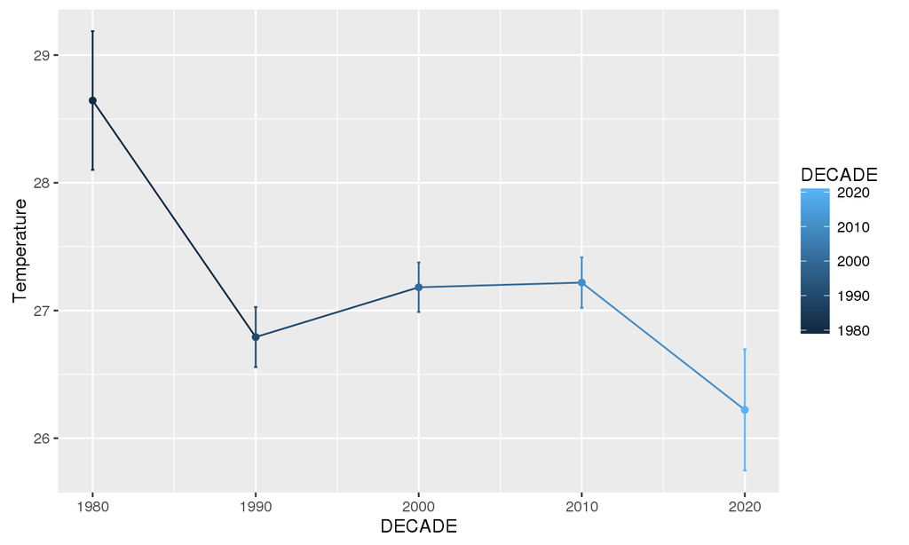

## Creating a Shiny App

## Create a Regression Line

```
## [1] "ID"          "YEAR"        "MONTH"       "ELEMENT"     "Day"
## [6] "Temperature" "DECADE"
```

```
## [1] "ID"          "YEAR"        "MONTH"       "ELEMENT"     "Day"
## [6] "Temperature" "DECADE"      "Date"
```

## Draft Plot

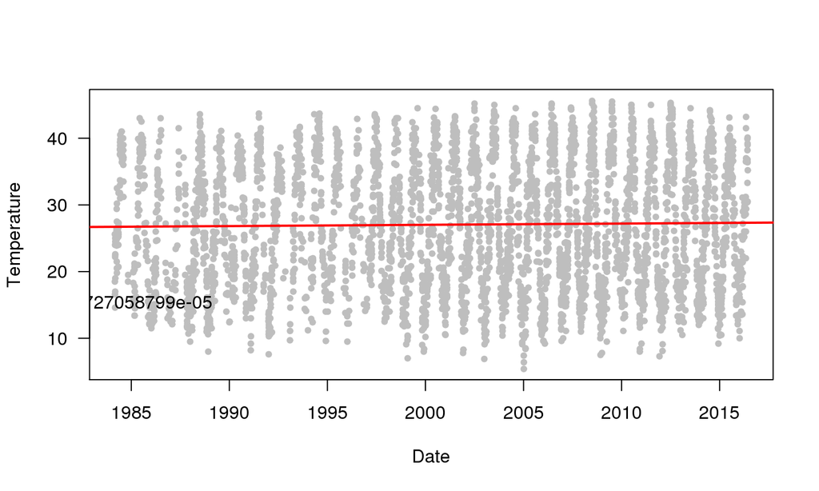

## Creating Flexible Dates

Create a range of inputs – by year.

```
##               ID YEAR MONTH ELEMENT Day Temperature DECADE       Date
## 1271 AGM00060515 1990     1    TMAX   1          NA   1990 1990-01-01
## 1272 AGM00060515 1990     2    TMAX   1          NA   1990 1990-02-01
## 1273 AGM00060515 1990     3    TMAX   1          NA   1990 1990-03-01
## 1274 AGM00060515 1990     4    TMAX   1        15.5   1990 1990-04-01
## 1275 AGM00060515 1990     5    TMAX   1        16.1   1990 1990-05-01
## 1276 AGM00060515 1990     6    TMAX   1          NA   1990 1990-06-01
```

## Create Update-able Plot

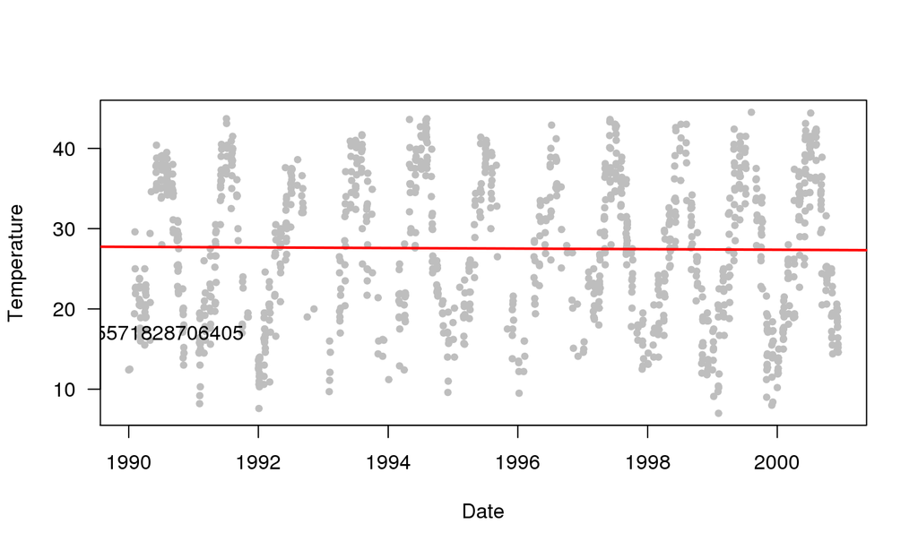

## Next Steps

## Developing a Shiny App

1. Pass Data to Shiny

## Create Reactive Inputs

1. Create Input Slider for min and max years
2. Create text to decribe results that are readable!
3. Add "output" to html text.